# Exploratory Data Analysis - 'DIE ZEIT' Churn Prediction

### **4.3 - ZON-Columns**

This data shows, in which of these services a user firstly registrated. Values differ from 0 to 2.  
`0 = not available`  
`1 = not finished`  
`2 = Registration confirmed`

```python
df.iloc[:, 21:35].info()
```

```
<class 'pandas.core.frame.DataFrame'>
Int64Index: 156428 entries, 33526 to 179778
Data columns (total 14 columns):
 #   Column               Non-Null Count   Dtype
---  ------               --------------   -----
 0   zon_che_opt_in       156428 non-null  int64
 1   zon_sit_opt_in       156428 non-null  int64
 2   zon_zp_grey          156428 non-null  int64
 3   zon_premium          156428 non-null  int64
 4   zon_boa              156428 non-null  int64
 5   zon_kommentar        156428 non-null  int64
 6   zon_sonstige         156428 non-null  int64
 7   zon_zp_red           156428 non-null  int64
 8   zon_rawr             156428 non-null  int64
 9   zon_community        156428 non-null  int64
 10  zon_app_sonstige     156428 non-null  int64
 11  zon_schach           156428 non-null  int64
 12  zon_blog_kommentare  156428 non-null  int64
 13  zon_quiz             156428 non-null  int64
dtypes: int64(14)
memory usage: 22.9 MB
```

**ZON-Columns and churn**

- Only for `zon_zp_grey`, `zon_premium`, `zon_sonstige` and `zon_zp_red` a relevant percentage of registrations can be found
- The other columns here don't have any valuable information.
- Accoriding to the graphs below, most of the users **don't register with any serives in the ZEITOnline services**

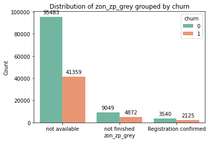

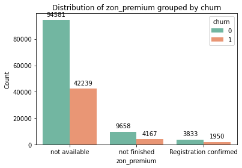

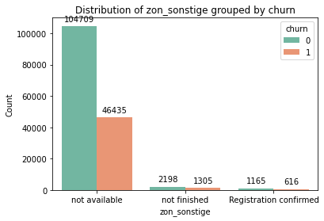

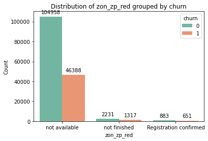

```python
relevant = ["zon_zp_grey", "zon_premium", "zon_sonstige", "zon_zp_red"]

for i in relevant:
    ax = sns.countplot(x=i, data=df, hue="churn", palette="Set2")
    ax.set(xlabel=i, ylabel="Count", xlim=[-0.5, 2.5])
    eda.add_count(ax)
    ax.set_xticklabels(["not available", "not finished", "Registration confirmed"])
    plt.title(f"Distribution of {i} grouped by churn")
    plt.show()
```

Let's inspect, if the registration to these services has an impact on the **churn rate**:

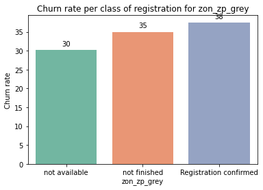

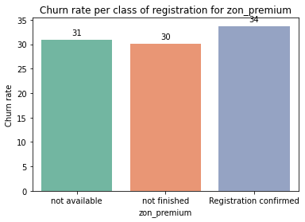

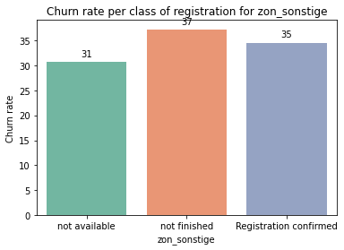

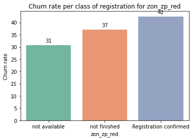

```python
relevant = ["zon_zp_grey", "zon_premium", "zon_sonstige", "zon_zp_red"]
for i in relevant:
    crosstab = eda.make_crosstab(df, i)
    g = sns.barplot(data=crosstab, x=i, y="True_per", palette="Set2")
    g.set_xlabel(i)
    g.set_ylabel("Churn rate")
    g.set_xticklabels(["not available", "not finished", "Registration confirmed"])
    eda.add_count(g)
    plt.title(f"Churn rate per class of registration for {i}")
    plt.show()
```

```python
df.zon_premium.value_counts()
```

```
0    136820
1     13825
2      5783
Name: zon_premium, dtype: int64
```

**Putting `0`and `1`into one variable**

```python
data_zon_alternative = df.copy()
```

```python
for i in data_zon_alternative.iloc[:, 21:35].columns:
    data_zon_alternative[i] = data_zon_alternative[i].apply(lambda x: 0 if x==0 or x==1 else 1)
```

```python
df.zon_premium.value_counts()
```

```
0    136820
1     13825
2      5783
Name: zon_premium, dtype: int64
```

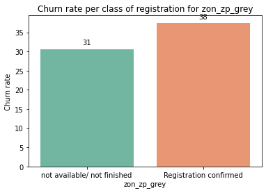

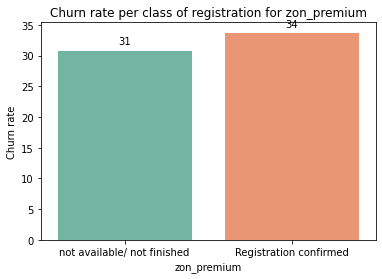

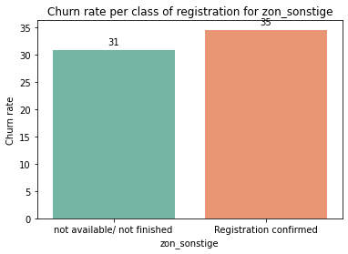

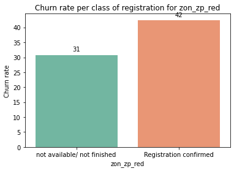

```python
relevant = ["zon_zp_grey", "zon_premium", "zon_sonstige", "zon_zp_red"]

for i in relevant:
    crosstab = eda.make_crosstab(data_zon_alternative, i)
    g = sns.barplot(data=crosstab, x=i, y="True_per", palette="Set2")
    g.set_xlabel(i)
    g.set_ylabel("Churn rate")
    g.set_xticklabels(["not available/ not finished", "Registration confirmed"])
    eda.add_count(g)
    plt.title(f"Churn rate per class of registration for {i}")
    plt.show()
```

If we do this feature engineering, the highest differnece in churn rate can bee seen for `zon_zp_red` followed by `zon_zp_grey`

|  | churn | zon_che_opt_in | zon_sit_opt_in | zon_zp_grey | zon_premium | zon_boa | zon_kommentar | zon_sonstige | zon_zp_red | zon_rawr | zon_community | zon_app_sonstige | zon_schach | zon_blog_kommentare | zon_quiz |
| --- | --- | --- | --- | --- | --- | --- | --- | --- | --- | --- | --- | --- | --- | --- | --- |
| churn | 1.000 | 0.010 | 0.020 | 0.040 | 0.010 | 0.020 | 0.010 | 0.020 | 0.030 | -0.000 | 0.010 | 0.010 | 0.000 | 0.000 | 0.000 |
| zon_che_opt_in | 0.010 | 1.000 | -0.000 | -0.010 | -0.010 | -0.000 | -0.000 | -0.000 | -0.010 | -0.000 | -0.000 | -0.000 | -0.000 | -0.000 | -0.000 |
| zon_sit_opt_in | 0.020 | -0.000 | 1.000 | -0.010 | -0.010 | -0.000 | -0.000 | -0.000 | -0.000 | -0.000 | -0.000 | -0.000 | -0.000 | -0.000 | -0.000 |
| zon_zp_grey | 0.040 | -0.010 | -0.010 | 1.000 | -0.100 | -0.020 | -0.010 | -0.050 | -0.050 | -0.000 | -0.000 | -0.010 | -0.000 | -0.000 | -0.000 |
| zon_premium | 0.010 | -0.010 | -0.010 | -0.100 | 1.000 | -0.020 | -0.010 | -0.050 | -0.050 | -0.000 | -0.000 | -0.010 | -0.010 | -0.010 | -0.000 |
| zon_boa | 0.020 | -0.000 | -0.000 | -0.020 | -0.020 | 1.000 | -0.000 | -0.010 | -0.010 | -0.000 | -0.000 | -0.000 | -0.000 | 0.000 | -0.000 |
| zon_kommentar | 0.010 | -0.000 | -0.000 | -0.010 | -0.010 | -0.000 | 1.000 | -0.010 | -0.010 | -0.000 | -0.000 | -0.000 | -0.000 | -0.000 | -0.000 |
| zon_sonstige | 0.020 | -0.000 | -0.000 | -0.050 | -0.050 | -0.010 | -0.010 | 1.000 | -0.030 | -0.000 | -0.000 | -0.010 | -0.000 | -0.000 | -0.000 |
| zon_zp_red | 0.030 | -0.010 | -0.000 | -0.050 | -0.050 | -0.010 | -0.010 | -0.030 | 1.000 | -0.000 | -0.000 | -0.010 | -0.000 | -0.000 | -0.000 |
| zon_rawr | -0.000 | -0.000 | -0.000 | -0.000 | -0.000 | -0.000 | -0.000 | -0.000 | -0.000 | 1.000 | -0.000 | -0.000 | -0.000 | -0.000 | -0.000 |
| zon_community | 0.010 | -0.000 | -0.000 | -0.000 | -0.000 | -0.000 | -0.000 | -0.000 | -0.000 | -0.000 | 1.000 | -0.000 | -0.000 | -0.000 | -0.000 |
| zon_app_sonstige | 0.010 | -0.000 | -0.000 | -0.010 | -0.010 | -0.000 | -0.000 | -0.010 | -0.010 | -0.000 | -0.000 | 1.000 | -0.000 | -0.000 | -0.000 |
| zon_schach | 0.000 | -0.000 | -0.000 | -0.000 | -0.010 | -0.000 | -0.000 | -0.000 | -0.000 | -0.000 | -0.000 | -0.000 | 1.000 | -0.000 | -0.000 |
| zon_blog_kommentare | 0.000 | -0.000 | -0.000 | -0.000 | -0.010 | 0.000 | -0.000 | -0.000 | -0.000 | -0.000 | -0.000 | -0.000 | -0.000 | 1.000 | -0.000 |
| zon_quiz | 0.000 | -0.000 | -0.000 | -0.000 | -0.000 | -0.000 | -0.000 | -0.000 | -0.000 | -0.000 | -0.000 | -0.000 | -0.000 | -0.000 | 1.000 |

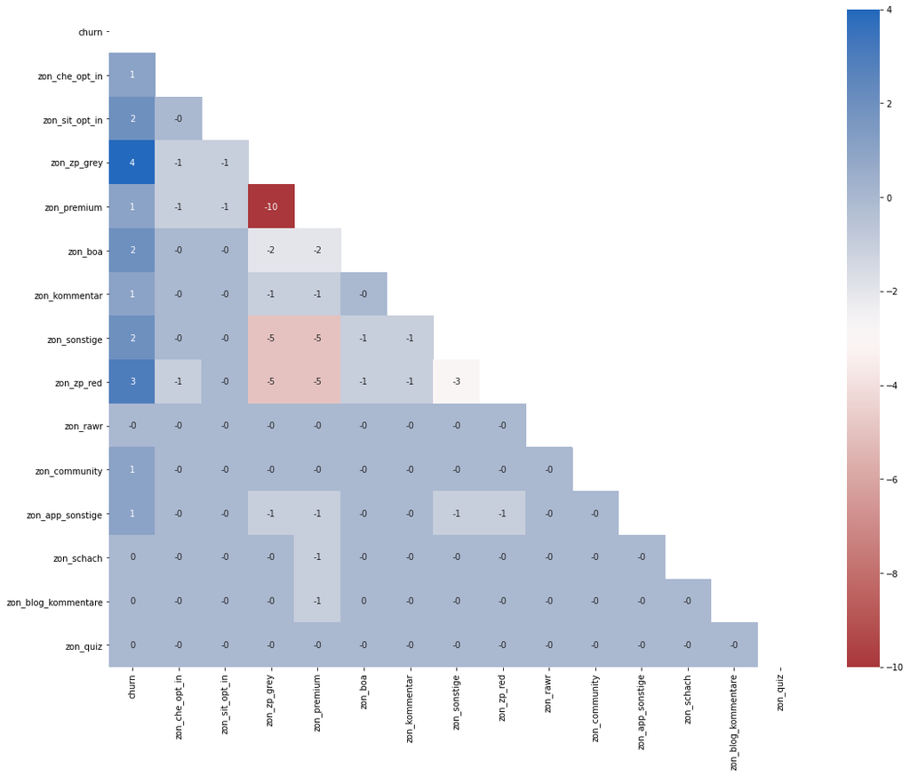

```python
df_corr_zon = df[['churn','zon_che_opt_in', 'zon_sit_opt_in', 'zon_zp_grey', 'zon_premium',
       'zon_boa', 'zon_kommentar', 'zon_sonstige', 'zon_zp_red', 'zon_rawr',
       'zon_community', 'zon_app_sonstige', 'zon_schach',
       'zon_blog_kommentare', 'zon_quiz']]
eda.correlation(df_corr_zon)
```

For these features **no significant correlations** on churn can be found which is not surprising, cause of their object, binary-like structure

### **4.4 - CNT-Columns**

- The cnt features contain information of how many additional and which additional subscribtion types are held by the `auftrag_new_id`.
- The column “cnt_abo” holds the sum of the other columns.

```python
df.iloc[:, 35:41].columns
```

```
Index(['cnt_abo', 'cnt_abo_diezeit', 'cnt_abo_diezeit_digital',
       'cnt_abo_magazin', 'cnt_umwandlungsstatus2_dkey',
       'abo_registrierung_min'],
      dtype='object')
```

**cnt_abo**

- we already cut the max abo count to 20, everything else is not feasible

```python
df.cnt_abo.describe()
```

```
count   156,428.000
mean          1.505
std           2.442
min           0.000
25%           0.000
50%           1.000
75%           2.000
max          20.000
Name: cnt_abo, dtype: float64
```

**Compare chrun rate for those, who have no additional subscription and who have at least one additional subscription**

- There is a difference in the churn rate
- 34% of the 73k subs who have no additional subscriptions churn
- only 28% of the 84k who have at least one additional subscription churn

```python
data_cnt_alternative = df
data_cnt_alternative["more_than_zero_cnt_abo"] = df["cnt_abo"].apply(lambda x: 0 if x==0 else 1)
```

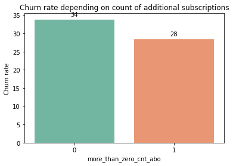

```python
crosstab = eda.make_crosstab(data_cnt_alternative, "more_than_zero_cnt_abo")

g = sns.barplot(data=crosstab, x= "more_than_zero_cnt_abo", y="True_per", palette="Set2")
g.set_ylabel("Churn rate")
eda.add_count(g)
plt.title(f"Churn rate depending on count of additional subscriptions")
plt.show()
```

**cnt_umwandlungsstatus2_dkey**

- This variable describes the count of the subscriptions, which turned from a test to a regular subscription
- Most of the values are in the range of 0 to 3

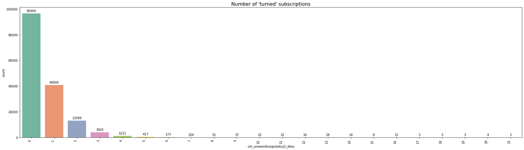

```python
plt.figure(figsize=(30,8))
f = sns.countplot(x=df.cnt_umwandlungsstatus2_dkey, data=df, palette="Set2");
f.set_xticklabels(f.get_xticklabels(), rotation=90, ha="right");
eda.add_count(f)
plt.title(f"Number of 'turned' subscriptions", fontsize=16);
```

**Create new features out of cnt_umwandlungsstatus2_dkey**

1. Feature, where `cnt_umwandlungsstatus2_dkey` == `cnt_abos`. But only, where `cnt_abo` > 0
2. Feature, where `cnt_umwandlungsstatus2_dkey` > 0
- we can see significant differences in the churn rates
- people who tested their subscription before paying for it are less likely to churn (25% vs. 35%)
- people who turned all their test-subscriptions into payed subs are even less likely to churn (21% vs. 33%)

```python
# for plotting we need to do it like this (we need to include "churn")
data_cnt_alternative2 = df
data_cnt_alternative2["cnt_dkey_equals_cnt_abo"] = data_cnt_alternative2.apply(lambda x: eda.dkey(x["cnt_umwandlungsstatus2_dkey"], x["cnt_abo"]), axis=1)
data_cnt_alternative2["cnt_dkey_more_than_one"] = data_cnt_alternative2.cnt_umwandlungsstatus2_dkey.apply(lambda x: 1 if x >0 else 0)
```

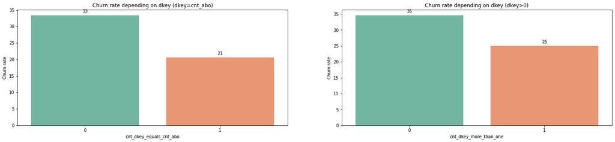

```python
fig, axes = plt.subplots(ncols=2, nrows=1, figsize=(25, 5))

crosstab= eda.make_crosstab(data_cnt_alternative2, "cnt_dkey_equals_cnt_abo")
crosstab2 = eda.make_crosstab(data_cnt_alternative2, "cnt_dkey_more_than_one")

g = sns.barplot(data=crosstab, x= "cnt_dkey_equals_cnt_abo", y="True_per", ax=axes[0], palette="Set2")
g.set_ylabel("Churn rate")
g.set_title(f"Churn rate depending on dkey (dkey=cnt_abo)")
eda.add_count(g)


g1 = sns.barplot(data=crosstab2, x= "cnt_dkey_more_than_one", y="True_per", ax=axes[1], palette="Set2")
g1.set_ylabel("Churn rate")
eda.add_count(g1)
g1.set_title(f"Churn rate depending on dkey (dkey>0)")
```

Below, correlations of the independent features & on churn can be seen.

- The positive correlations are coming from the fact, that they are aggregates
- For example, `cnt_abo` holds the sum of the following three variables
- In the modelling part, we have to consider this to avoid multicollinearity

|  | churn | cnt_abo | cnt_abo_diezeit | cnt_abo_diezeit_digital | cnt_abo_magazin | cnt_umwandlungsstatus2_dkey |
| --- | --- | --- | --- | --- | --- | --- |
| churn | 1.000 | 0.020 | 0.030 | 0.030 | -0.030 | -0.060 |
| cnt_abo | 0.020 | 1.000 | 0.940 | 0.360 | 0.520 | 0.560 |
| cnt_abo_diezeit | 0.030 | 0.940 | 1.000 | 0.150 | 0.310 | 0.420 |
| cnt_abo_diezeit_digital | 0.030 | 0.360 | 0.150 | 1.000 | 0.100 | 0.270 |
| cnt_abo_magazin | -0.030 | 0.520 | 0.310 | 0.100 | 1.000 | 0.480 |
| cnt_umwandlungsstatus2_dkey | -0.060 | 0.560 | 0.420 | 0.270 | 0.480 | 1.000 |

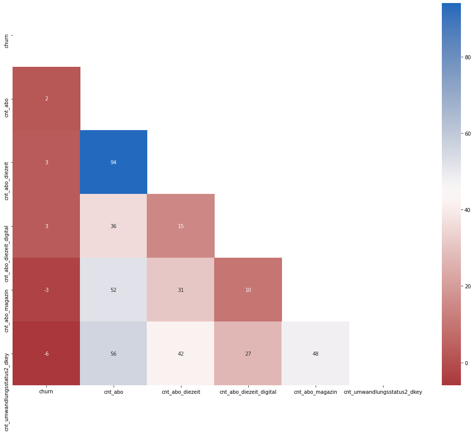

```python
df_cnt_corr = df[['churn','cnt_abo', 'cnt_abo_diezeit', 'cnt_abo_diezeit_digital',
       'cnt_abo_magazin', 'cnt_umwandlungsstatus2_dkey',
       'abo_registrierung_min']]
eda.correlation(df_cnt_corr)
```

### **4.5 - NL-Columns**

- This data shows, in which of these newsletters a user is registered.
- Values differ from 0 to 2.  
  `0 = not available`  
  `1 = unsubscribed`  
  `2 = active`
- There are three different Newsletters in this dataset: ZEITBRIEF, ZEITSHOP and ZEITVERLAG HAMBURG (ELBVERTIEFUNG)
- A majority of **62.4%** of our paying subs receive the Zeitbrief-Newsletter
- **12.1%** of the subscribers receive the Zeitshop-Newsletter
- Only **4.8%** of the subscribers receive the Zeitverlag-Newsletter

```python
df.iloc[:, 41:51].info()
```

```
<class 'pandas.core.frame.DataFrame'>
Int64Index: 156428 entries, 33526 to 179778
Data columns (total 10 columns):
 #   Column                 Non-Null Count   Dtype
---  ------                 --------------   -----
 0   nl_zeitbrief           156428 non-null  int64
 1   nl_zeitshop            156428 non-null  int64
 2   nl_zeitverlag_hamburg  156428 non-null  int64
 3   nl_fdz_organisch       156428 non-null  int64
 4   nl_blacklist_dum       156428 non-null  int64
 5   nl_bounced_dum         156428 non-null  int64
 6   nl_aktivitaet          156428 non-null  int64
 7   nl_registrierung_min   156428 non-null  object
 8   nl_sperrliste_dum      156428 non-null  int64
 9   nl_opt_in_dum          156428 non-null  int64
dtypes: int64(9), object(1)
memory usage: 18.1+ MB
```

**Distribution of the newsletters**

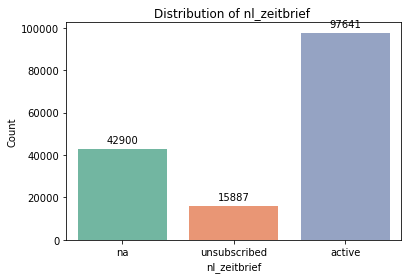

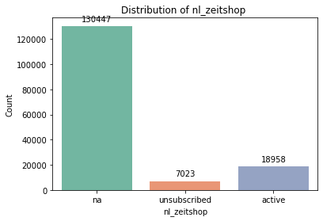

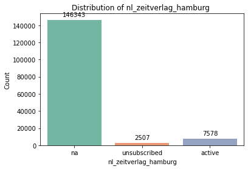

```python
relevant = ["nl_zeitbrief", "nl_zeitshop", "nl_zeitverlag_hamburg"]
for i in relevant:
    ax = sns.countplot(x=i, data=df, palette="Set2")
    ax.set(xlabel=i, ylabel="Count", xlim=[-0.5, 2.5])
    ax.set_xticklabels(["na", "unsubscribed", "active"])
    eda.add_count(ax)
    plt.title(f"Distribution of {i} ")
    plt.show()
    print("\n")
```

**NL-Columns and churn**

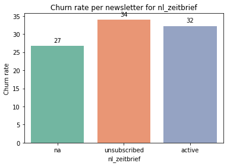

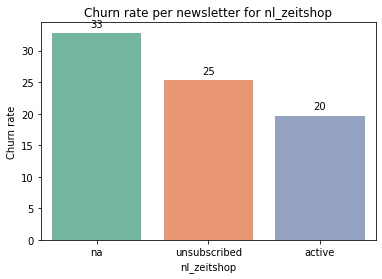

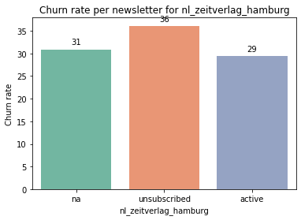

```python
relevant = ["nl_zeitbrief", "nl_zeitshop", "nl_zeitverlag_hamburg"]
for i in relevant:
    crosstab = eda.make_crosstab(df, i)
    g = sns.barplot(data=crosstab, x=i, y="True_per", palette="Set2")
    g.set_xlabel(i)
    g.set_ylabel("Churn rate")
    g.set_xticklabels(["na", "unsubscribed", "active"])
    eda.add_count(g)
    plt.title(f"Churn rate per newsletter for {i}")
    plt.show()
```

`ZEITBRIEF: and ZEITVERLAG HAMBURG`--> Highest churn rate for the unsubscirbed users  
`ZEITSHOP`--> Highest churn rate for not available information. Lowest for active users.

- It can be concluded, that there **is variance regarding the churn rate** when it comes to the newsletters
- The Zeitshop Newsletter seems to have the biggest positive impact regarding customers churning with only 20% of the receivers churning
- This might be a good marketing strategie for the Churn Prevention Mailing

**nl_fdz_organisch**

- Because of the non-significant number of members of this loyalty program, this feature is not further inspected

```python
df.nl_fdz_organisch.value_counts(0)
```

```
0    156363
1        65
Name: nl_fdz_organisch, dtype: int64
```

**nl_blacklist_dum, nl_bounced_dum and nl_sperrliste_dum**

`nl_blacklist_dum`: if your email adress is blacklisted 33% of the people tend to churn, this could be because of a lack of interest in updating your account infos and therefore the subscription in genereall.

`nl_bounced_dum`: if NL sent bei the Zeitverlag bounce, the churn probability is lower, a possible explanation could be that the recipients regard NL as spam

`nl_sperrliste_dum`: no difference and low count

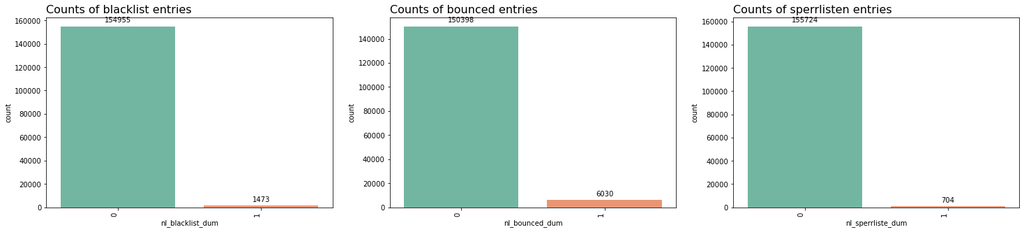

```python
fig, axes = plt.subplots(ncols=3, nrows=1, figsize=(25, 5))

f = sns.countplot(x=df.nl_blacklist_dum, data=df, palette="Set2", ax=axes[0]);
f.set_xticklabels(f.get_xticklabels(), rotation=90, ha="right");
f.set_title("Counts of blacklist entries", fontsize=16, loc="left")
eda.add_count(f)


f1 = sns.countplot(x=df.nl_bounced_dum, data=df, palette="Set2", ax=axes[1]);
f1.set_xticklabels(f.get_xticklabels(), rotation=90, ha="right");
f1.set_title("Counts of bounced entries", fontsize=16, loc="left")
eda.add_count(f1)


f2 = sns.countplot(x=df.nl_sperrliste_dum, data=df, palette="Set2", ax=axes[2]);
f2.set_xticklabels(f.get_xticklabels(), rotation=90, ha="right");
f2.set_title("Counts of sperrlisten entries", fontsize=16, loc="left")
eda.add_count(f2)
```

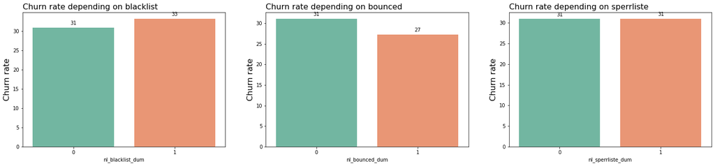

```python
fig, axes = plt.subplots(ncols=3, nrows=1, figsize=(25, 5))

crosstab1 = eda.make_crosstab(df, "nl_blacklist_dum")
crosstab2 = eda.make_crosstab(df, "nl_bounced_dum")
crosstab3 = eda.make_crosstab(df, "nl_sperrliste_dum")

g1 = sns.barplot(data=crosstab1, x= "nl_blacklist_dum", y="True_per", palette="Set2", ax=axes[0])
g1.set_ylabel("Churn rate", size=16)
g1.set_title("Churn rate depending on blacklist", fontsize=16, loc="left");
eda.add_count(g1)

g2 = sns.barplot(data=crosstab2, x= "nl_bounced_dum", y="True_per", palette="Set2", ax=axes[1])
g2.set_ylabel("Churn rate", size=16)
g2.set_title("Churn rate depending on bounced", fontsize=16, loc="left");
eda.add_count(g2)

g3 = sns.barplot(data=crosstab3, x= "nl_sperrliste_dum", y="True_per", palette="Set2", ax=axes[2])
g3.set_ylabel("Churn rate", size=16)
g3.set_title("Churn rate depending on sperrliste", fontsize=16, loc="left");
eda.add_count(g3)
```

**nl_aktivitaet**

This feature contains the count of subscriptions to all available Newsletters, not only for those in this dataset:

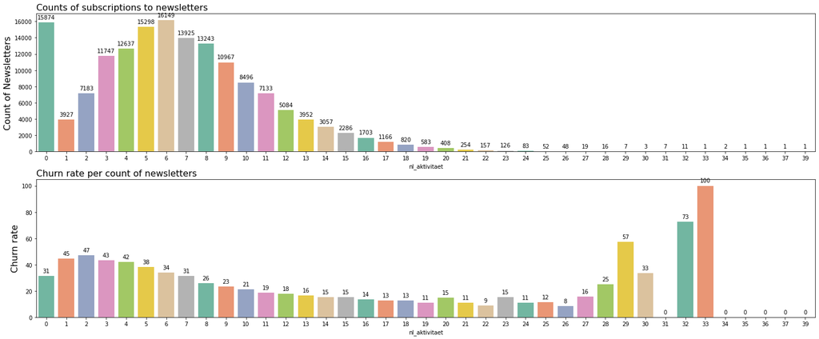

```python
fig, axes = plt.subplots(ncols=1, nrows=2, figsize=(25, 10))
crosstab = eda.make_crosstab(df, "nl_aktivitaet")


f = sns.countplot(x=df.nl_aktivitaet, data=df, ax=axes[0], palette="Set2");
f.set_ylabel("Count of Newsletters", size=16)
f.set_title("Counts of subscriptions to newsletters", fontsize=16, loc="left");
eda.add_count(f)

g = sns.barplot(data=crosstab, x="nl_aktivitaet", y="True_per", ax=axes[1], palette="Set2")
g.set_ylabel("Churn rate", size=16)
g.set_title(f"Churn rate per count of newsletters", loc="left", fontsize=16);
eda.add_count(g)
```

There are differences between the absolute counts and the relative values for churn rates. The max value for the absolute number of newsletters is 6, whereas the churn rate for the same number is compareably low. It can be concluded, that there are **differences in the churn rate regarding the number of newsletters.**

```python
df["nl_registrierung_min_YEAR"] = df["nl_registrierung_min"].apply(lambda x: x.split()[0].split("-")[0])
df = df.sort_values(by=['nl_registrierung_min'])
```

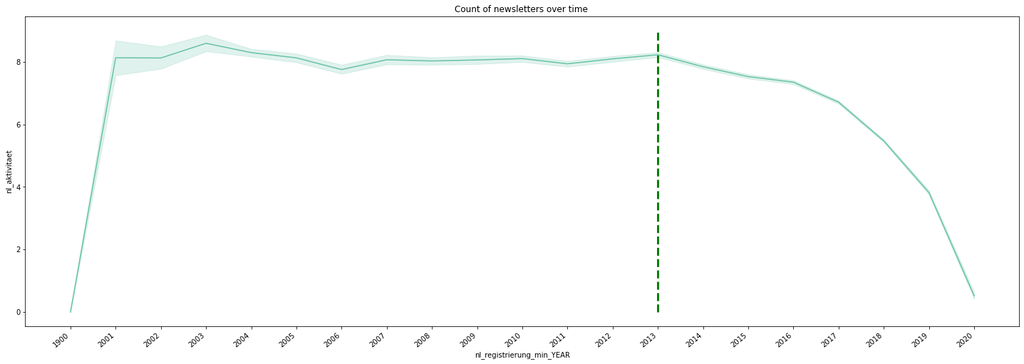

```python
labels = sorted(list(set([i for i in df["nl_registrierung_min_YEAR"]])))

plt.figure(figsize=(25,8))
plt.title("Count of newsletters over time ")
g = sns.lineplot(data=df, x="nl_registrierung_min_YEAR", y="nl_aktivitaet")
g.set_xticklabels(labels, rotation=40, ha="right");
plt.vlines(x=13,ymin=0,ymax=9,lw=3,linestyles='--',colors="g")
```

- Apparently, die Zeit keeps track of newsletters **since 2001.**
- Following the year **2013**, the number of newsletters **decreases**

|  | churn | nl_zeitbrief | nl_zeitshop | nl_zeitverlag_hamburg | nl_fdz_organisch | nl_blacklist_dum | nl_bounced_dum | nl_aktivitaet | nl_sperrliste_dum | nl_opt_in_dum |
| --- | --- | --- | --- | --- | --- | --- | --- | --- | --- | --- |
| churn | 1.000 | 0.050 | -0.100 | -0.000 | 0.020 | 0.000 | -0.020 | -0.170 | 0.000 | 0.020 |
| nl_zeitbrief | 0.050 | 1.000 | 0.070 | 0.090 | -0.000 | 0.030 | 0.110 | 0.460 | -0.030 | 0.050 |
| nl_zeitshop | -0.100 | 0.070 | 1.000 | 0.010 | 0.000 | 0.040 | 0.080 | 0.260 | 0.010 | 0.000 |
| nl_zeitverlag_hamburg | -0.000 | 0.090 | 0.010 | 1.000 | -0.000 | 0.010 | 0.030 | 0.150 | -0.000 | 0.020 |
| nl_fdz_organisch | 0.020 | -0.000 | 0.000 | -0.000 | 1.000 | -0.000 | -0.000 | 0.010 | 0.000 | 0.000 |
| nl_blacklist_dum | 0.000 | 0.030 | 0.040 | 0.010 | -0.000 | 1.000 | 0.000 | 0.010 | 0.090 | 0.000 |
| nl_bounced_dum | -0.020 | 0.110 | 0.080 | 0.030 | -0.000 | 0.000 | 1.000 | 0.040 | 0.000 | -0.000 |
| nl_aktivitaet | -0.170 | 0.460 | 0.260 | 0.150 | 0.010 | 0.010 | 0.040 | 1.000 | -0.040 | 0.220 |
| nl_sperrliste_dum | 0.000 | -0.030 | 0.010 | -0.000 | 0.000 | 0.090 | 0.000 | -0.040 | 1.000 | -0.000 |
| nl_opt_in_dum | 0.020 | 0.050 | 0.000 | 0.020 | 0.000 | 0.000 | -0.000 | 0.220 | -0.000 | 1.000 |

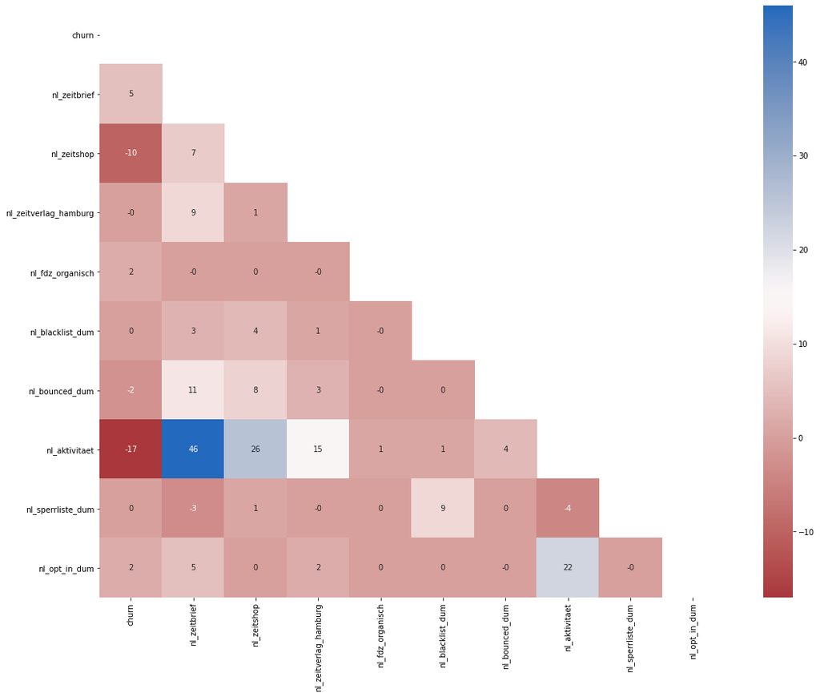

```python
df_corr_nl = df[['churn', 'nl_zeitbrief', 'nl_zeitshop', 'nl_zeitverlag_hamburg',
       'nl_fdz_organisch', 'nl_blacklist_dum', 'nl_bounced_dum',
       'nl_aktivitaet', 'nl_registrierung_min', 'nl_sperrliste_dum',
       'nl_opt_in_dum']]
eda.correlation(df_corr_nl)
```

A correlation can only be found between `nl_aktivitaet` and `nl_zeitbrief`

### **4.6 - Reg-Columns**

This data shows, in which of these services a user is registered. Values differ from 0 to 1.  
`0 = not registered`  
`1 = registered`  
`boa_reg` --> BOA: Berufsorientierung für Absolventen (job orientation for graduates)  
`che_reg` --> CHE: Hochschullranking (College Ranking)  
`sit_reg` --> SIT: Studium Interessentest (Study interest test)  
`sso_reg` --> SSO: Single Sign On

Counts: Only for `sso_reg` there are more registrations than users, who didn't register. The single sign on authentification is necessary for various online services.

Churning rates:

- The most significant differences between registered users and non-registered users can be found for `boa_reg` and `sso_reg`
- For BOA: if the service helps graduates find a job quickly it is plausible that you keep your payed subscription because of higher purchasing power and because you benefited from this free to use Zeit-service

```python
df.iloc[:, 51:55].info()
```

```
<class 'pandas.core.frame.DataFrame'>
Int64Index: 156428 entries, 103720 to 174307
Data columns (total 4 columns):
 #   Column   Non-Null Count   Dtype
---  ------   --------------   -----
 0   boa_reg  156428 non-null  int64
 1   che_reg  156428 non-null  int64
 2   sit_reg  156428 non-null  int64
 3   sso_reg  156428 non-null  int64
dtypes: int64(4)
memory usage: 6.0 MB
```

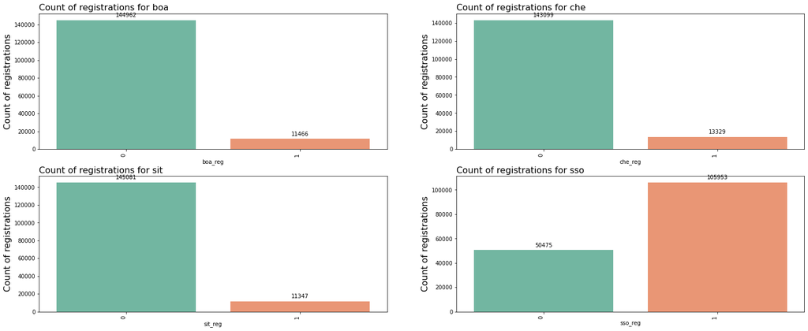

```python
fig, axes = plt.subplots(ncols=2, nrows=2, figsize=(25, 10))

f = sns.countplot(x=df.boa_reg, data=df, palette="Set2",ax=axes[0,0]);
f.set_xticklabels(f.get_xticklabels(), rotation=90, ha="right");
f.set_ylabel("Count of registrations", size=16)
f.set_title("Count of registrations for boa", fontsize=16, loc="left");
eda.add_count(f)

f1 = sns.countplot(x=df.che_reg, data=df, palette="Set2",ax=axes[0,1]);
f1.set_xticklabels(f.get_xticklabels(), rotation=90, ha="right");
f1.set_ylabel("Count of registrations", size=16)
f1.set_title("Count of registrations for che", fontsize=16, loc="left");
eda.add_count(f1)

f2 = sns.countplot(x=df.sit_reg, data=df,palette="Set2", ax=axes[1,0]);
f2.set_xticklabels(f.get_xticklabels(), rotation=90, ha="right");
f2.set_ylabel("Count of registrations", size=16)
f2.set_title("Count of registrations for sit", fontsize=16, loc="left");
eda.add_count(f2)

f3 = sns.countplot(x=df.sso_reg, data=df, palette="Set2", ax=axes[1,1]);
f3.set_xticklabels(f.get_xticklabels(), rotation=90, ha="right");
f3.set_ylabel("Count of registrations", size=16)
f3.set_title("Count of registrations for sso", fontsize=16, loc="left");
eda.add_count(f3)
```

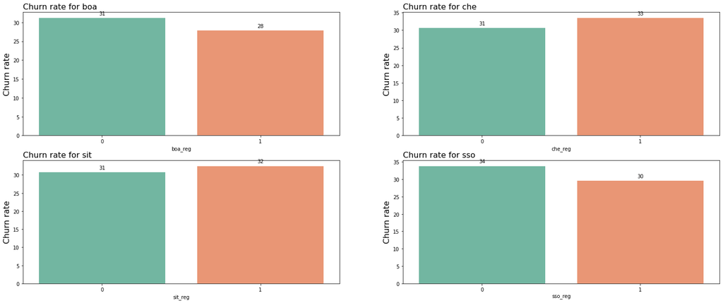

```python
fig, axes = plt.subplots(ncols=2, nrows=2, figsize=(25, 10))
crosstab1= eda.make_crosstab(df, "boa_reg")
crosstab2= eda.make_crosstab(df, "che_reg")
crosstab3= eda.make_crosstab(df, "sit_reg")
crosstab4= eda.make_crosstab(df, "sso_reg")

g1 = sns.barplot(data=crosstab1, x= "boa_reg", y="True_per", palette="Set2", ax=axes[0,0])
g1.set_ylabel("Churn rate", size=16)
g1.set_title("Churn rate for boa", fontsize=16, loc="left");
eda.add_count(g1)


g2 = sns.barplot(data=crosstab2, x= "che_reg", y="True_per", palette="Set2", ax=axes[0,1])
g2.set_ylabel("Churn rate", size=16)
g2.set_title("Churn rate for che", fontsize=16, loc="left");
eda.add_count(g2)


g3 = sns.barplot(data=crosstab3, x= "sit_reg", y="True_per", palette="Set2", ax=axes[1,0])
g3.set_ylabel("Churn rate", size=16)
g3.set_title("Churn rate for sit", fontsize=16, loc="left");
eda.add_count(g3)

g4 = sns.barplot(data=crosstab4, x= "sso_reg", y="True_per", palette="Set2", ax=axes[1,1])
g4.set_ylabel("Churn rate", size=16)
g4.set_title("Churn rate for sso", fontsize=16, loc="left");
eda.add_count(g4)
```

### **4.7 - Newsletter-Columns**

- we have 5 collections of data regarding subscriptions to different Newsletters
- they are all structured like this:

| `Column name` | Time Period |
| --- | --- |
| received_anzahl | 1 week, 1 month, 3 months, 6 months |
| opened_anzahl | 1 week, 1 month, 3 months, 6 months |
| clicked_anzahl | 1 week, 1 month, 3 months, 6 months |
| unsubscribed_anzahl | 1 week, 1 month, 3 months, 6 months |
| openrate | 1 week, 1 month, 3 months |
| clickrate | 1 week, 1 month, 3 months |

#### **4.7.1 - E-Mails Totally Received by ALL Customers (df_tot)**

This data frame contains information about the **total amount of emails sent to (all) customers** for different time periods.

```python
# Identify index of column ranges that have to be dropped

# Defining block 1
start_ind_1 = df.columns.get_loc('zon_che_opt_in')
end_ind_1 = df.columns.get_loc('sso_reg')
# Defining block 2
start_ind_2 = df.columns.get_loc('received_anzahl_produktnews_1w')
end_ind_2 = df.columns.get_loc('clickrate_zeitbrief_3m')

# Generate variables containing the index

cols1 = [i for i in range(start_ind_1, end_ind_1 + 1)]   # Slice 1
cols2 = [i for i in range(start_ind_2, end_ind_2 + 1)]   # Slice 2
# Convert to list type
cols1 = list(df.columns[cols1])
cols2 = list(df.columns[cols2])

# Finally drop the columns

df_c = df.drop(columns=cols1, axis=1)                    # c = customized
df_c = df_c.drop(columns=cols2, axis=1)
```

```python
# df_tot -->> data frame contains information about all received emails (tot = total)

# Define block to be dropped (Subset containing 'Erhalten insg ...' (engl. totally received)
start_ind_1 = df_c.columns.get_loc('liefer_beginn_evt')
end_ind_1 = df_c.columns.get_loc('received_anzahl_1w')

# Drop first set of columns
df_tot = df_c.drop(df_c.iloc[:, start_ind_1:end_ind_1], axis=1)

# Define another block to be dropped
start_ind_2 = df_tot.columns.get_loc('received_anzahl_bestandskunden_1w')
end_ind_2 = df_tot.columns.get_loc('churn')

df_tot = df_tot.drop(df_tot.iloc[:, start_ind_2:end_ind_2], axis=1)

# Drop 'date_x'
df_tot = df_tot.drop(labels='date_x', axis=1)
```

**Check the features by churn (for aggregated values - max period)**

```
(0.0, 20000.0)
```

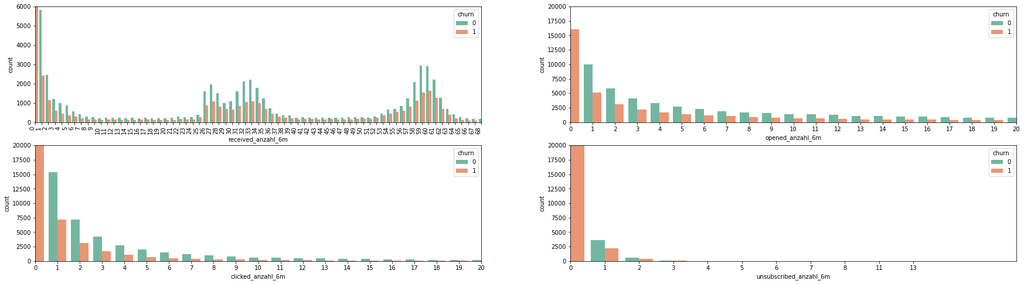

```python
fig, axes = plt.subplots(ncols=2, nrows=2, figsize=(30, 8), sharey=False)

sns.countplot(data=df_tot, x='received_anzahl_6m', hue='churn', ax=axes[0,0], palette="Set2")
axes[0,0].set_xlim(0, 68)
axes[0,0].set_ylim(0, 6000)
axes[0,0].set_xticklabels(axes[0,0].get_xticklabels(), rotation=90, ha="right");
sns.countplot(data=df_tot, x='opened_anzahl_6m', hue='churn', ax=axes[0,1], palette="Set2")
axes[0,1].set_xlim(0, 20)
axes[0,1].set_ylim(0, 20000)
sns.countplot(data=df_tot, x='clicked_anzahl_6m', hue='churn', ax=axes[1,0], palette="Set2")
axes[1,0].set_xlim(0, 20)
axes[1,0].set_ylim(0, 20000)
sns.countplot(data=df_tot, x='unsubscribed_anzahl_6m', hue='churn', ax=axes[1,1], palette="Set2")
axes[1,1].set_xlim(0, 13)
axes[1,1].set_ylim(0, 20000)
```

```
(0.0, 2000.0)
```

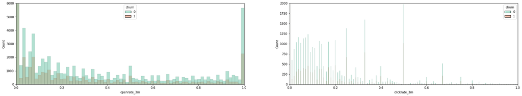

```python
fig, axes = plt.subplots(ncols=2, nrows=1, figsize=(30, 5), sharey=False)

sns.histplot(data=df_tot, x='openrate_3m', hue='churn', ax=axes[0], palette="Set2")
axes[0].set_xlim(0, 1.0)
axes[0].set_ylim(0, 6000)

sns.histplot(data=df_tot, x='clickrate_3m', hue='churn', ax=axes[1], palette="Set2")
plt.xlim(0, 1.0)
axes[1].set_xlim(0, 1.0)
axes[1].set_ylim(0, 2000)
```

**Conclusion:**

- The previous analysis is looking at the aggregated values for newsletters the customers received in the past 6 months.
- The column `received_anzahl` has been interpreted as the total amount of newsletters a customer received.
- As the calculated sum for `received_anzahl_6m_All` does not match the sum for `received_anzahl_6m_Newsletter`, we assume that total amount of received newsletters (`received_anzahl_6m`) does also contains counts of newsletters which are not given in the data set.

#### **4.7.2 - E-Mails Received by ESTABLISHED Customers (df_e_cust)**

```python
# df_e_cust -->> data frame contains information about emails established customers received

# Define block to be deleted (Subset containing 'Erhalten aus dem Bestandskundenmandanten ...' (engl. Received from existing customer))
start_ind_1 = df_c.columns.get_loc('liefer_beginn_evt')
end_ind_1 = df_c.columns.get_loc('received_anzahl_bestandskunden_1w')

# Drop first set of columns
df_e_cust = df_c.drop(df_c.iloc[:, start_ind_1:end_ind_1], axis=1)

# Drop further columns
df_e_cust = df_e_cust.drop(labels=['training_set', 'kuendigungs_eingangs_datum', 'date_x'], axis=1)
```

**Check the features by churn (for aggregated values - 6 months)**

```
(0.0, 10000.0)
```

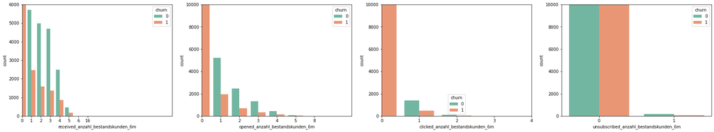

```python
fig, axes = plt.subplots(ncols=4, nrows=1, figsize=(30, 5), sharey=False)

sns.countplot(data=df_e_cust, x='received_anzahl_bestandskunden_6m', hue='churn', ax=axes[0], palette="Set2")
axes[0].set_xlim(0, 16)
axes[0].set_ylim(0, 6000)
sns.countplot(data=df_e_cust, x='opened_anzahl_bestandskunden_6m', hue='churn', ax=axes[1], palette="Set2")
axes[1].set_xlim(0, 8)
axes[1].set_ylim(0, 10000)
sns.countplot(data=df_e_cust, x='clicked_anzahl_bestandskunden_6m', hue='churn', ax=axes[2], palette="Set2")
axes[2].set_xlim(0, 4)
axes[2].set_ylim(0, 10000)
sns.countplot(data=df_e_cust, x='unsubscribed_anzahl_bestandskunden_6m', hue='churn', ax=axes[3], palette="Set2")
axes[3].set_xlim(-0.5, 1.5)
axes[3].set_ylim(0, 10000)
```

#### **4.7.3 - Productnews (data_productnews)**

```python
# creating productnews dataframe with important variables that could influence the target value

# abonnement status variable
data_abo_status = df[['nl_zeitverlag_hamburg','nl_fdz_organisch', 'nl_blacklist_dum',
                    'nl_bounced_dum','nl_aktivitaet','nl_registrierung_min','nl_sperrliste_dum']]

# Initial 21 columns which contains demographic information
data_demo = df.iloc[:,0:21]

# columns with variables related to produktnews
data_productnews = df.iloc[:,99:121]

# target variable
data_target = df['churn']

# combining all the splits to create new producktnews dataframe
EDA_produktnews = pd.concat([data_demo, data_abo_status, data_productnews, data_target], axis=1)
```

Let's create a table of missing, duplicates and unique values along with datatype information

```python
eda.meta(EDA_produktnews)
```

| varname | liefer_beginn_evt | clicked_anzahl_produktnews_3m | received_anzahl_produktnews_1w | received_anzahl_produktnews_1m | received_anzahl_produktnews_3m | received_anzahl_produktnews_6m | opened_anzahl_produktnews_1w | opened_anzahl_produktnews_1m | opened_anzahl_produktnews_3m | opened_anzahl_produktnews_6m | clicked_anzahl_produktnews_1w | clicked_anzahl_produktnews_1m | clicked_anzahl_produktnews_6m | nl_registrierung_min | unsubscribed_anzahl_produktnews_1w | unsubscribed_anzahl_produktnews_1m | unsubscribed_anzahl_produktnews_3m | unsubscribed_anzahl_produktnews_6m | openrate_produktnews_1w | clickrate_produktnews_1w | openrate_produktnews_1m | clickrate_produktnews_1m | openrate_produktnews_3m | clickrate_produktnews_3m | nl_sperrliste_dum | nl_aktivitaet | kanal | ort | objekt_name | … |
| --- | --- | --- | --- | --- | --- | --- | --- | --- | --- | --- | --- | --- | --- | --- | --- | --- | --- | --- | --- | --- | --- | --- | --- | --- | --- | --- | --- | --- | --- | --- |
| nulls | 0 | 0 | 0 | 0 | 0 | 0 | 0 | 0 | 0 | 0 | 0 | 0 | 0 | 0 | 0 | 0 | 0 | 0 | 0 | 0 | 0 | 0 | 0 | 0 | 0 | 0 | 0 | 0 | 0 | … |
| percent | 0.000 | 0.000 | 0.000 | 0.000 | 0.000 | 0.000 | 0.000 | 0.000 | 0.000 | 0.000 | 0.000 | 0.000 | 0.000 | 0.000 | 0.000 | 0.000 | 0.000 | 0.000 | 0.000 | 0.000 | 0.000 | 0.000 | 0.000 | 0.000 | 0.000 | 0.000 | 0.000 | 0.000 | 0.000 | … |
| dtype | object | int64 | int64 | int64 | int64 | int64 | int64 | int64 | int64 | int64 | int64 | int64 | int64 | object | int64 | int64 | int64 | int64 | float64 | float64 | float64 | float64 | float64 | float64 | int64 | int64 | object | object | object | … |
| dup | True | True | True | True | True | True | True | True | True | True | True | True | True | True | True | True | True | True | True | True | True | True | True | True | True | True | True | True | True | … |
| nuniques | 406 | 8 | 5 | 9 | 13 | 14 | 5 | 9 | 11 | 12 | 5 | 6 | 8 | 117766 | 2 | 2 | 2 | 2 | 7 | 6 | 19 | 16 | 25 | 23 | 2 | 39 | 10 | 11347 | 3 | … |

**Cause all aggregates correlate, we only consider aggregates of max period for our EDA**

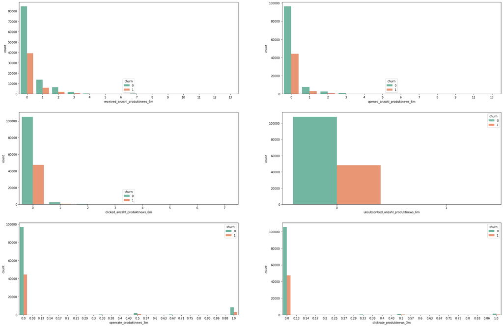

```python
fig, axes = plt.subplots(ncols=2, nrows=3, figsize=(30, 20), sharey=False)

sns.countplot(data=EDA_produktnews, x="received_anzahl_produktnews_6m", hue='churn', ax=axes[0][0], palette="Set2")
sns.countplot(data=EDA_produktnews, x="opened_anzahl_produktnews_6m", hue='churn', ax=axes[0][1], palette="Set2")
sns.countplot(data=EDA_produktnews, x="clicked_anzahl_produktnews_6m", hue='churn', ax=axes[1][0], palette="Set2")
sns.countplot(data=EDA_produktnews, x="unsubscribed_anzahl_produktnews_6m", hue='churn', ax=axes[1][1], palette="Set2")
sns.countplot(data=EDA_produktnews, x="openrate_produktnews_3m", hue='churn', ax=axes[2][0], palette="Set2")
sns.countplot(data=EDA_produktnews, x="clickrate_produktnews_3m", hue='churn', ax=axes[2][1], palette="Set2");
```

#### **4.7.4 - Hamburg-Newsletter (data_hamburg)**

"Hamburg newsletter - Elbvertiefung – Der tägliche Newsletter für Hamburg"

Hamburg / Elbvertiefung is the new daily ZEIT newsletter for Hamburg.

**Hamburg - Newsletter stats:**

- there are 7k subscribers to the newsletter (received it at least 1 in the last 6m)
- 93% of the subscribers received more than 100 newsletters in the last 6m

```python
# columns with variables related to hamburg newsletter
data_hamburg = df.iloc[:,121:143]

# combining all the splits to create new producktnews dataframe
EDA_hamburg = pd.concat([data_demo, data_abo_status, data_hamburg, data_target], axis=1)
```

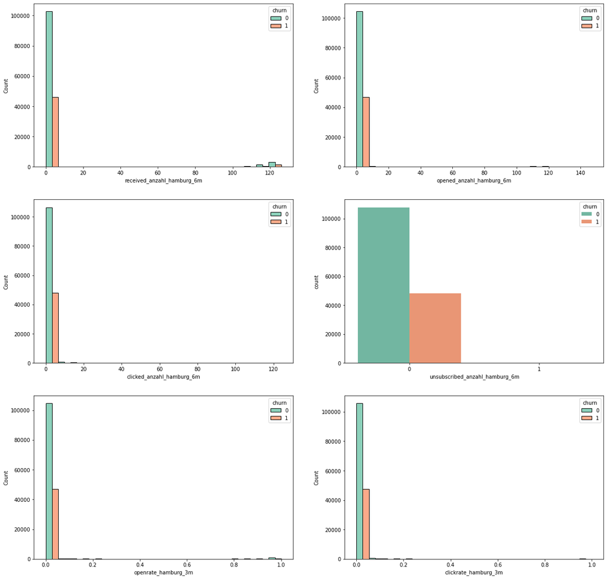

```python
fig, axes = plt.subplots(ncols=2, nrows=3, figsize=(20, 20), sharey=False)

sns.histplot(data=df, x="received_anzahl_hamburg_6m", hue='churn', ax=axes[0][0], multiple = "dodge", palette="Set2")
sns.histplot(data=df, x="opened_anzahl_hamburg_6m", hue='churn', ax=axes[0][1], multiple = "dodge",  palette="Set2")
sns.histplot(data=df, x="clicked_anzahl_hamburg_6m", hue='churn', ax=axes[1][0], multiple = "dodge", palette="Set2")
sns.countplot(data=df, x="unsubscribed_anzahl_hamburg_6m", hue='churn', ax=axes[1][1], palette="Set2")
sns.histplot(data=df, x="openrate_hamburg_3m", hue='churn', ax=axes[2][0], multiple = "dodge", palette="Set2")
sns.histplot(data=df, x="clickrate_hamburg_3m", hue='churn', ax=axes[2][1], multiple = "dodge", palette="Set2");
```

#### **4.7.5 - ZEITBRIEF-Newsletter**

"Erfahren Sie am Mittwoch, was für Sie drin ist. Wir informieren Sie per Mail über die Themen und Inhalte der aktuellen gedruckten ZEIT und natürlich darüber, was Sie bei ZEIT ONLINE finden."

- is a special kind of weekly newsletter
- is sent every wednesday and features the recently covered topics of the print issue and what's found on Zeit Online

**Zeitbrief - Newsletter stats:**

```python
df_zeitbrief = df.drop(df.iloc[:, 22:143], axis=1)
```

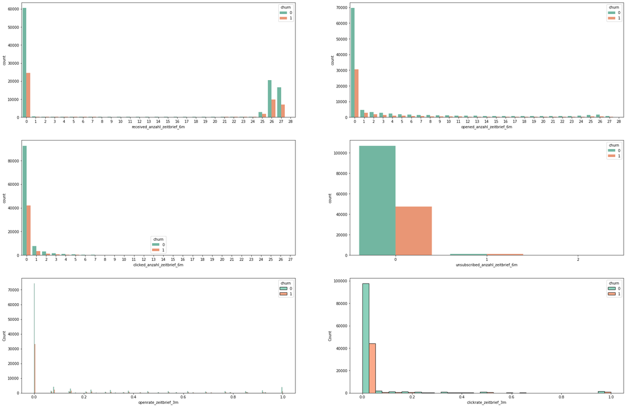

```python
fig, axes = plt.subplots(ncols=2, nrows=3, figsize=(30, 20), sharey=False)

sns.countplot(data=df, x="received_anzahl_zeitbrief_6m", hue='churn', ax=axes[0][0], palette="Set2")
sns.countplot(data=df, x="opened_anzahl_zeitbrief_6m", hue='churn', ax=axes[0][1], palette="Set2")
sns.countplot(data=df, x="clicked_anzahl_zeitbrief_6m", hue='churn', ax=axes[1][0], palette="Set2")
sns.countplot(data=df, x="unsubscribed_anzahl_zeitbrief_6m", hue='churn', ax=axes[1][1], palette="Set2")
sns.histplot(data=df, x="openrate_zeitbrief_3m", hue='churn', ax=axes[2][0], multiple = "dodge", palette="Set2")
sns.histplot(data=df, x="clickrate_zeitbrief_3m", hue='churn', ax=axes[2][1], multiple = "dodge", palette="Set2");
```

**Inconsistency Check** </br> Create Subset of all the 71k people who received at least 1 Zeitbrief Newsletter:

```python
df_zb_abo = df.query('received_anzahl_zeitbrief_6m > 0')
df_zb_abo.shape
```

```
(71198, 175)
```

Check active users regarding the column nl_zeitbrief:

```python
df.nl_zeitbrief.value_counts()
```

```
2    97641
0    42900
1    15887
Name: nl_zeitbrief, dtype: int64
```

**Inconsitency within the Zeitbrief & generall data:**

- The variable 'nl_zeitbrief' relates to subscribers to the Zeitbrief - Newsletter.
- There 98k active subscribers but only 71k subscribers who actually received at least 1 newsletter i.t.l.6M which might be a result of a bad Data Architecture because of wrongly tuned APIs
- In the subset df_weird we got 27.5k subscribers who subscribed to the NL but received no newsletters in the last 6 months.
- People who receive the NL-Zeitbrief tend to churn more frequent (32%) than the overall sample (30.9%), so it might not be a good idea to adress them.

Checking correlations for the aggregate maxima & the matching NL columns against `churn`

|  | churn | received_anzahl_6m | received_anzahl_bestandskunden_6m | received_anzahl_produktnews_6m | received_anzahl_hamburg_6m | received_anzahl_zeitbrief_6m |
| --- | --- | --- | --- | --- | --- | --- |
| churn | 1.000 | -0.090 | -0.050 | -0.030 | -0.000 | 0.030 |
| received_anzahl_6m | -0.090 | 1.000 | 0.100 | 0.050 | 0.400 | 0.380 |
| received_anzahl_bestandskunden_6m | -0.050 | 0.100 | 1.000 | 0.530 | 0.010 | 0.120 |
| received_anzahl_produktnews_6m | -0.030 | 0.050 | 0.530 | 1.000 | 0.010 | 0.040 |
| received_anzahl_hamburg_6m | -0.000 | 0.400 | 0.010 | 0.010 | 1.000 | 0.090 |
| received_anzahl_zeitbrief_6m | 0.030 | 0.380 | 0.120 | 0.040 | 0.090 | 1.000 |

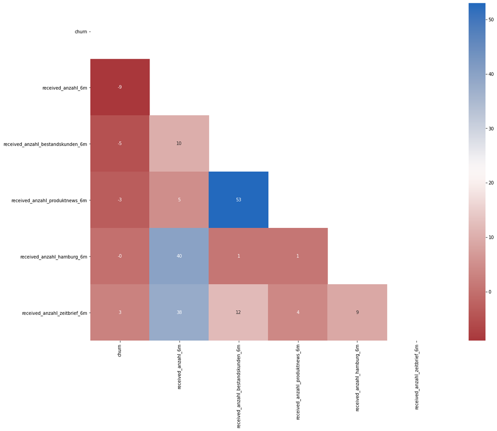

```python
df_corr_nl2 = df[['churn', 'received_anzahl_6m', 'received_anzahl_bestandskunden_6m', 'received_anzahl_produktnews_6m', 'received_anzahl_hamburg_6m', 'received_anzahl_zeitbrief_6m']]
eda.correlation(df_corr_nl2)
```

## 5. Feature Engineering

We work on our cleaned dataset and export a feature-engineered data set, so we can keep track of the effects our feature engineering had on our models:

ZON - Features: we create dummies out of the 14 ZON features with 3 categories, we also add 1 aggregation function as most of the columns have >99% zeros:

### ZON - Features

```python
for i in df.iloc[: ,21:35]:
    df[i] = df[i].apply(eda.todumm)

agg_zon = df.iloc[: ,21:35].sum(axis=1) # this aggregation function should check wether a user is
```

```python
agg_zon.value_counts()
```

```
0    141240
1     15063
2       125
dtype: int64
```

```python
agg_zon = agg_zon.to_frame(name="agg_zon")
df_doubles = df.join(agg_zon)
```

#### Error Analysis on Zon-Features:

```python
df_doubles = df_doubles.query("agg_zon == 2").iloc[: , 21:35]
```

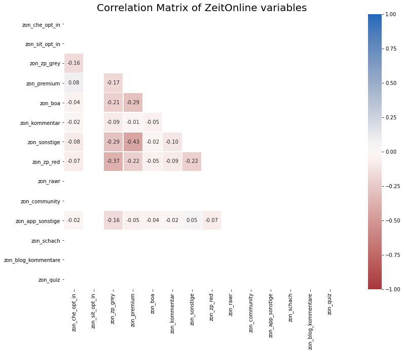

```python
corr = df_doubles.corr()
mask = np.zeros_like(corr, dtype=np.bool)
mask[np.triu_indices_from(mask)] = True
#cmap = sns.diverging_palette(220, 10, as_cmap=True) (diverging not necessary)
f, ax = plt.subplots(figsize=(20, 10))
sns.heatmap(corr, mask=mask,square=True, linewidths=.5, annot=True, vmin=-1, vmax=1, center= 0, fmt='.2f' , cmap="vlag_r")
plt.yticks(rotation=0)
plt.title('Correlation Matrix of ZeitOnline variables', fontsize=20)
plt.show()
```

```python
df_doubles.sort_values(['zon_premium','zon_sonstige'], ascending=[False,False]).head(5)
```

|  | zon_che_opt_in | zon_sit_opt_in | zon_zp_grey | zon_premium | zon_boa | zon_kommentar | zon_sonstige | zon_zp_red | zon_rawr | zon_community | zon_app_sonstige | zon_schach | zon_blog_kommentare | zon_quiz |
| --- | --- | --- | --- | --- | --- | --- | --- | --- | --- | --- | --- | --- | --- | --- |
| 193339 | 0 | 0 | 0 | 1 | 0 | 0 | 1 | 0 | 0 | 0 | 0 | 0 | 0 | 0 |
| 113315 | 0 | 0 | 0 | 1 | 0 | 0 | 1 | 0 | 0 | 0 | 0 | 0 | 0 | 0 |
| 84369 | 0 | 0 | 0 | 1 | 0 | 0 | 1 | 0 | 0 | 0 | 0 | 0 | 0 | 0 |
| 113756 | 0 | 0 | 0 | 1 | 0 | 0 | 1 | 0 | 0 | 0 | 0 | 0 | 0 | 0 |
| 131490 | 0 | 0 | 0 | 1 | 0 | 0 | 1 | 0 | 0 | 0 | 0 | 0 | 0 | 0 |

```python
df.query('zon_premium == 1 & zon_sonstige ==1')
```

|  | liefer_beginn_evt | kanal | objekt_name | aboform_name | zahlung_rhythmus_name | lesedauer | rechnungsmonat | zahlung_weg_name | studentenabo | plz_1 | plz_2 | plz_3 | ort | metropole | land_iso_code | shop_kauf | unterbrechung | anrede | titel | avg_churn | email_am_kunden | zon_che_opt_in | zon_sit_opt_in | zon_zp_grey | zon_premium | zon_boa | zon_kommentar | zon_sonstige | zon_zp_red | … |
| --- | --- | --- | --- | --- | --- | --- | --- | --- | --- | --- | --- | --- | --- | --- | --- | --- | --- | --- | --- | --- | --- | --- | --- | --- | --- | --- | --- | --- | --- | --- |
| 193339 | 2019-01-30 | andere | ZEIT Digital | Festabo | jährlich | 8 | 0 | Bankeinzug | 0 | 1 | 16 | 165 | Glienicke | 0 | DE | 0 | 0 | Frau | kein Titel | 0.350 | 1.000 | 0 | 0 | 0 | 1 | 0 | 0 | 1 | 0 | … |
| 113315 | 2017-06-22 | Eigenwerbung | DIE ZEIT | Probeabo | jährlich | 27 | 0 | Bankeinzug | 0 | 1 | 16 | 165 | Glienicke | 0 | DE | 0 | 0 | Frau | kein Titel | 0.184 | 1.000 | 0 | 0 | 0 | 1 | 0 | 0 | 1 | 0 | … |
| 84369 | 2017-05-11 | Telefonmarketing | ZEIT Digital | Festabo | jährlich | 25 | 0 | Bankeinzug | 0 | 2 | 22 | 225 | Hamburg | 1 | DE | 1 | 0 | Herr | kein Titel | 0.279 | 1.000 | 0 | 0 | 0 | 1 | 0 | 0 | 1 | 0 | … |
| 113756 | 2017-11-16 | andere | ZEIT Digital | Negative Option | jährlich | 26 | 0 | Rechnung | 0 | 2 | 28 | 288 | Stuhr | 0 | DE | 0 | 0 | Frau | akademischer Titel | 0.292 | 1.000 | 0 | 0 | 0 | 1 | 0 | 0 | 1 | 0 | … |
| 131490 | 2018-08-29 | E-Mailing | ZEIT Digital | Negative Option | jährlich | 11 | 0 | Rechnung | 0 | 1 | 12 | 124 | Berlin | 1 | DE | 3 | 0 | Frau | kein Titel | 0.611 | 1.000 | 0 | 0 | 0 | 1 | 0 | 0 | 1 | 0 | … |
| 68510 | 2016-06-02 | Mailings | DIE ZEIT | Festabo | jährlich | 40 | 0 | Bankeinzug | 0 | 2 | 24 | 242 | Schwedeneck | 0 | DE | 0 | 0 | Herr | akademischer Titel | 0.134 | 1.000 | 0 | 0 | 0 | 1 | 0 | 0 | 1 | 0 | … |
| 129370 | 2018-10-18 | SEA | DIE ZEIT | Negative Option | halbjährlich | 9 | 0 | Bankeinzug | 0 | 1 | 12 | 121 | Berlin | 1 | DE | 0 | 0 | Herr | kein Titel | 0.514 | 1.000 | 0 | 0 | 0 | 1 | 0 | 0 | 1 | 0 | … |
| 95240 | 2017-12-14 | andere | ZEIT Digital | Negative Option | jährlich | 18 | 0 | Rechnung | 0 | 6 | 66 | 665 | Neunkirchen | 0 | DE | 0 | 0 | Herr | kein Titel | 0.198 | 1.000 | 0 | 0 | 0 | 1 | 0 | 0 | 1 | 0 | … |
| 176829 | 2018-08-15 | andere | ZEIT Digital | Festabo | jährlich | 11 | 0 | Rechnung | 0 | 8 | 81 | 818 | München | 1 | DE | 10 | 0 | Herr | akademischer Titel | 0.611 | 1.000 | 0 | 0 | 0 | 1 | 0 | 0 | 1 | 0 | … |
| 41301 | 2017-01-12 | Eigenwerbung | DIE ZEIT | Probeabo | jährlich | 38 | 0 | Rechnung | 0 | 8 | 81 | 818 | München | 1 | DE | 10 | 1 | Herr | akademischer Titel | 0.226 | 1.000 | 0 | 0 | 0 | 1 | 0 | 0 | 1 | 0 | … |
| 123310 | 2017-04-20 | andere | ZEIT Digital | Festabo | jährlich | 34 | 0 | Bankeinzug | 0 | 3 | 32 | 320 | Herford | 0 | DE | 0 | 0 | Herr | kein Titel | 0.243 | 1.000 | 0 | 0 | 0 | 1 | 0 | 0 | 1 | 0 | … |
| 89801 | 2017-08-24 | E-Mailing | ZEIT Digital | Negative Option | jährlich | 28 | 0 | Rechnung | 0 | 8 | 89 | 890 | Ulm | 0 | DE | 0 | 0 | Frau | kein Titel | 0.130 | 1.000 | 0 | 0 | 0 | 1 | 0 | 0 | 1 | 0 | … |
| 150677 | 2017-10-05 | Telefonmarketing | DIE ZEIT | Probeabo | jährlich | 29 | 0 | Bankeinzug | 0 | 8 | 89 | 890 | Ulm | 0 | DE | 0 | 0 | Frau | kein Titel | 0.153 | 1.000 | 0 | 0 | 0 | 1 | 0 | 0 | 1 | 0 | … |
| 95684 | 2017-12-04 | andere | ZEIT Digital | Festabo | jährlich | 27 | 0 | Bankeinzug | 0 | 2 | 28 | 283 | Bremen | 1 | DE | 0 | 0 | Herr | akademischer Titel | 0.184 | 1.000 | 0 | 0 | 0 | 1 | 0 | 0 | 1 | 0 | … |
| 120730 | 2017-11-16 | E-Mailing | DIE ZEIT | Negative Option | halbjährlich | 19 | 0 | Bankeinzug | 0 | 8 | 80 | 808 | München | 1 | DE | 2 | 0 | Herr | akademischer Titel | 0.428 | 1.000 | 0 | 0 | 0 | 1 | 0 | 0 | 1 | 0 | … |

### NL-Features

0 Nicht vorhanden, 1: Abgemeldet, 2: Aktiv

We also transform those to dummies, like we already did with nl_blacklist_sum, nl_bounced_sum, nl_sperrliste_sum, nl_opt_in_sum in outlier handling:

```python
for i in df.iloc[: , lambda df: [41,42,43,44]]:
    df[i] = df[i].apply(eda.todumm)
```

### Zeitreihen:

Fill missing Values (in Final_EDA needs to be added at the top):

```python
df.kuendigungs_eingangs_datum.fillna(value='2020-05-26', inplace=True)
```

Convert object-columns to datetime

```python
df['liefer_beginn_evt']= pd.to_datetime(df['liefer_beginn_evt'])
df['kuendigungs_eingangs_datum']= pd.to_datetime(df['kuendigungs_eingangs_datum'])
df['abo_registrierung_min']= pd.to_datetime(df['abo_registrierung_min'])
df['nl_registrierung_min']= pd.to_datetime(df['nl_registrierung_min'])
```

### Vetragsdauer vs. Lesedauer:

as "Lesedauer" is generated on the randomly selected "date_x" for non-churners, we will add 2 more representative columns `vertragsdauer_tage` & `vertragsdauer_monate`:

```python
df['vertragsdauer_tage'] = (df['kuendigungs_eingangs_datum'] - df['liefer_beginn_evt']).dt.days
```

```python
df['vertragsdauer_monate'] = df['vertragsdauer_tage'].apply(lambda x: x / 30).round().astype(int)
```

```python
df_1 = df.query('vertragsdauer_monate < 10')
df_1.aboform_name.value_counts(1)
```

```
Negative Option   0.622
Festabo           0.248
Probeabo          0.106
Geschenkabo       0.020
Prämienabo        0.005
Name: aboform_name, dtype: float64
```

#### Comparison of subscription counts for `vertragsdauer_monate` & `lesedauer`:

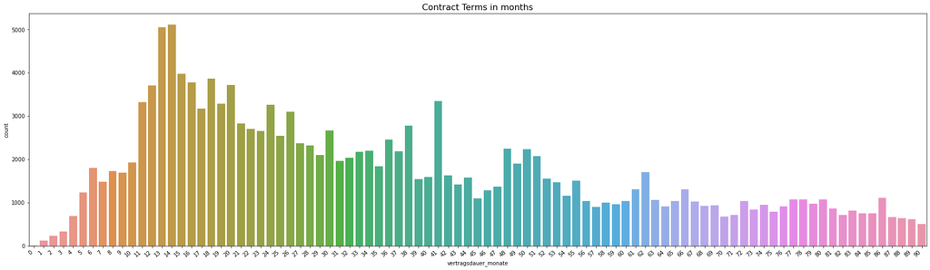

```python
plt.figure(figsize=(30,8))
f = sns.countplot(x=df.vertragsdauer_monate, data=df);
f.set_title("Contract Terms in months", fontsize=16);
f.set_xticklabels(f.get_xticklabels(), rotation=40, ha="right");
```

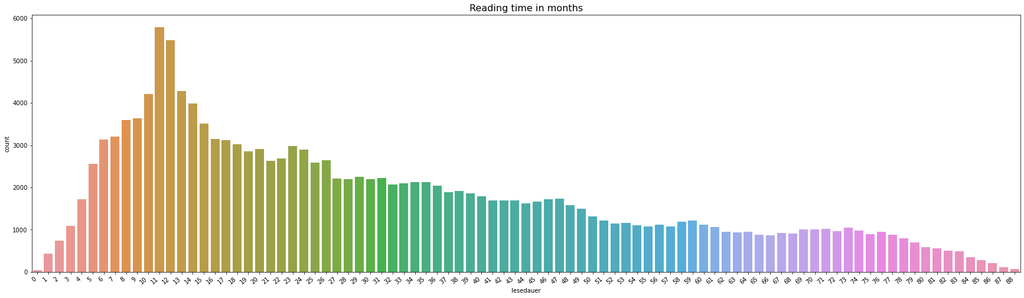

```python
plt.figure(figsize=(30,8))
f = sns.countplot(x=df.lesedauer, data=df);
f.set_title("Reading time in months", fontsize=16);
f.set_xticklabels(f.get_xticklabels(), rotation=40, ha="right");
```

#### Comparision of churners & non-churners for `vertragsdauer_monate` & `lesedauer`:

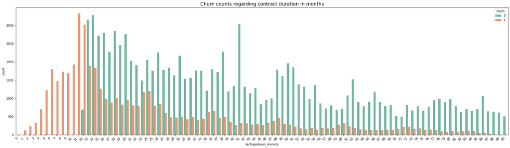

```python
plt.figure(figsize=(30,8))
custom_palette_2 = ["navy", "indianred"]
f = sns.countplot(x=df.vertragsdauer_monate, data=df, hue="churn", palette="Set2");
f.set_title("Churn counts regarding contract duration in months", fontsize=16);
f.set_xticklabels(f.get_xticklabels(), rotation=40, ha="right");
```

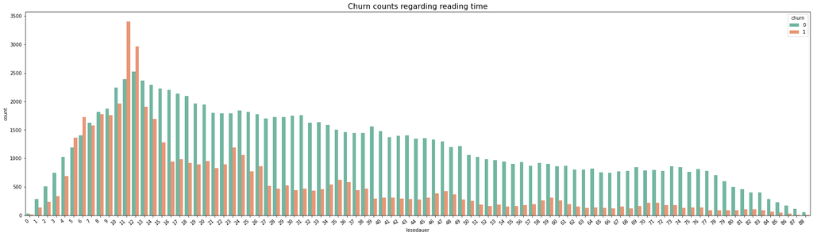

```python
plt.figure(figsize=(30,8))
custom_palette_2 = ["navy", "indianred"]
f = sns.countplot(x=df.lesedauer, data=df, hue="churn", palette="Set2");
f.set_title("Churn counts regarding reading time", fontsize=16);
f.set_xticklabels(f.get_xticklabels(), rotation=40, ha="right");
```

#### Comparision of churner ratios for `vertragsdauer_monate` & `lesedauer`:

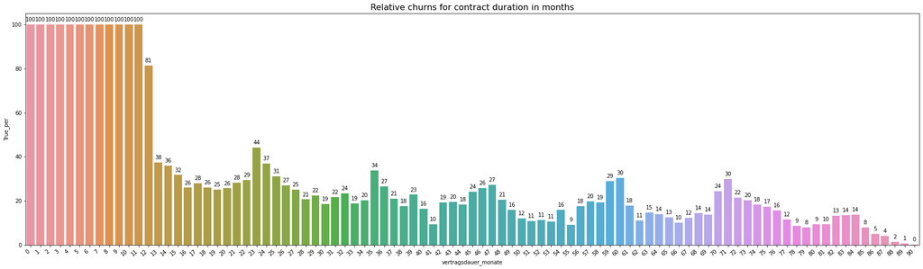

```python
crosstab_vertragsdauer = eda.make_crosstab(df, "vertragsdauer_monate")

plt.figure(figsize=(30,8))
f3 = sns.barplot(data=crosstab_vertragsdauer, x='vertragsdauer_monate', y="True_per")
f3.set_title("Relative churns for contract duration in months", fontsize=16);
f3.set_xticklabels(f3.get_xticklabels(),rotation=40, ha="right");
eda.add_count(f3)
```

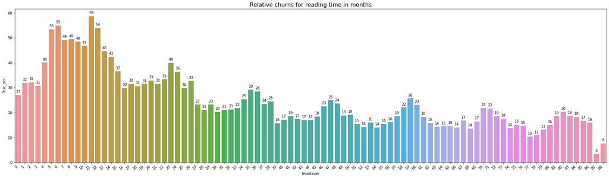

```python
crosstab_lesedauer = eda.make_crosstab(df, "lesedauer")

plt.figure(figsize=(30,8))
f3 = sns.barplot(data=crosstab_lesedauer, x="lesedauer", y="True_per")
f3.set_title("Relative churns for reading time in months", fontsize=16);
f3.set_xticklabels(f3.get_xticklabels(),rotation=40, ha="right");
eda.add_count(f3)
```

## Summarize:

- Our final dartaframe now has 177 features and 156,428 row
- we dropped just the unique value colums '''auftrags_id`&`unnamed```
- we created 8 new features

## Check our cleaned & feature engineneered dataset & export it:

```python
eda.meta(df).T
```

| varname | nulls | percent | dtype | dup | nuniques |
| --- | --- | --- | --- | --- | --- |
| liefer_beginn_evt | 0 | 0.000 | datetime64[ns] | True | 406 |
| unsubscribed_anzahl_bestandskunden_1w | 0 | 0.000 | int64 | True | 2 |
| unsubscribed_anzahl_produktnews_3m | 0 | 0.000 | int64 | True | 2 |
| unsubscribed_anzahl_produktnews_6m | 0 | 0.000 | int64 | True | 2 |
| openrate_produktnews_1w | 0 | 0.000 | float64 | True | 7 |
| clickrate_produktnews_1w | 0 | 0.000 | float64 | True | 6 |
| openrate_produktnews_1m | 0 | 0.000 | float64 | True | 19 |
| clickrate_produktnews_1m | 0 | 0.000 | float64 | True | 16 |
| openrate_produktnews_3m | 0 | 0.000 | float64 | True | 25 |
| clickrate_produktnews_3m | 0 | 0.000 | float64 | True | 23 |
| received_anzahl_hamburg_1w | 0 | 0.000 | int64 | True | 9 |
| received_anzahl_hamburg_1m | 0 | 0.000 | int64 | True | 30 |
| received_anzahl_hamburg_3m | 0 | 0.000 | int64 | True | 73 |
| received_anzahl_hamburg_6m | 0 | 0.000 | int64 | True | 125 |
| opened_anzahl_hamburg_1w | 0 | 0.000 | int64 | True | 9 |
| opened_anzahl_hamburg_1m | 0 | 0.000 | int64 | True | 30 |
| opened_anzahl_hamburg_3m | 0 | 0.000 | int64 | True | 73 |
| opened_anzahl_hamburg_6m | 0 | 0.000 | int64 | True | 130 |
| clicked_anzahl_hamburg_1w | 0 | 0.000 | int64 | True | 9 |
| clicked_anzahl_hamburg_1m | 0 | 0.000 | int64 | True | 27 |
| clicked_anzahl_hamburg_3m | 0 | 0.000 | int64 | True | 69 |
| unsubscribed_anzahl_produktnews_1m | 0 | 0.000 | int64 | True | 2 |
| unsubscribed_anzahl_produktnews_1w | 0 | 0.000 | int64 | True | 2 |
| clicked_anzahl_produktnews_6m | 0 | 0.000 | int64 | True | 8 |
| received_anzahl_produktnews_1w | 0 | 0.000 | int64 | True | 5 |
| unsubscribed_anzahl_bestandskunden_3m | 0 | 0.000 | int64 | True | 2 |
| unsubscribed_anzahl_bestandskunden_6m | 0 | 0.000 | int64 | True | 2 |
| openrate_bestandskunden_1w | 0 | 0.000 | float64 | True | 2 |
| clickrate_bestandskunden_1w | 0 | 0.000 | float64 | True | 2 |
| openrate_bestandskunden_1m | 0 | 0.000 | float64 | True | 3 |

[output cut: 147 more lines]

```python
df.to_csv('00_data/f_chtr_churn_traintable_nf_df_cleaned.csv')
```

```python
df_dup.to_csv('00_data/f_chtr_churn_traintable_nf_df_dup_cleaned.csv')
```